# 데이터 시각화

## 2.2 심미성 매핑

심미성 매핑(aesthetic mapping)은 데이터의 변수를 시각적 속성에 연결하는 과정을 의미하며, 앞서 보았듯이 `aes()` 함수 안에서 지정된다. x축과 y축을 지정하거나, 변수에 따라서 색상, 크기, 투명도 등을 다르게 부여하는 것이 대표적인 심미성 매핑의 예시이다. 앞서 그린 그래프를 종에 따라서 점 색상이 다르게 나타나도록 해보자. `color` 속성을 이용하면 된다.

```r
# 심미성: 색상
ggplot(data = iris, aes(x = Petal.Length, y = Petal.Width, color = Species)) +
    geom_point()
```

[output not shown]

점의 형태나 크기, 투명도도 종에 따라 다르게 부여할 수 있다.

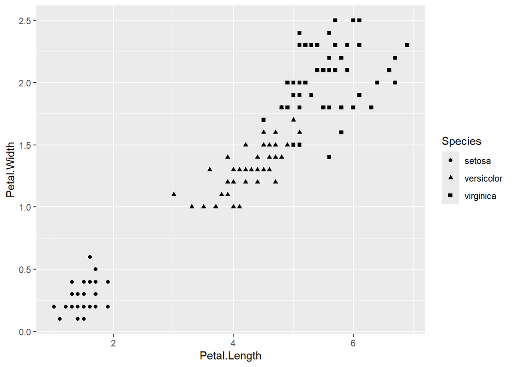

```r
# 심미성: 형태
ggplot(data = iris, aes(x = Petal.Length, y = Petal.Width, shape = Species)) +
    geom_point()
```

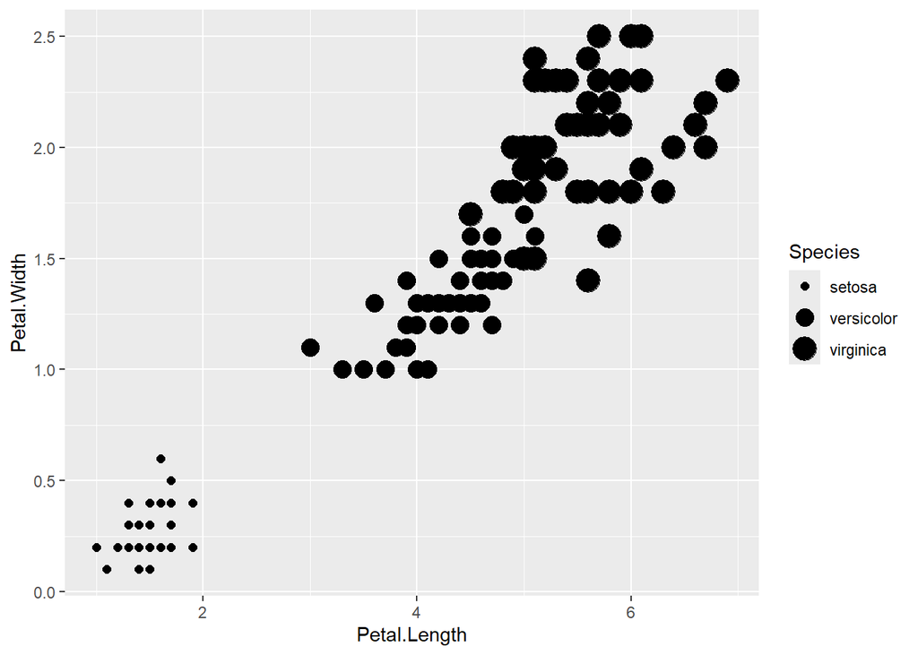

```r
# 심미성: 크기
ggplot(data = iris, aes(x = Petal.Length, y = Petal.Width, size = Species)) +
    geom_point()
```

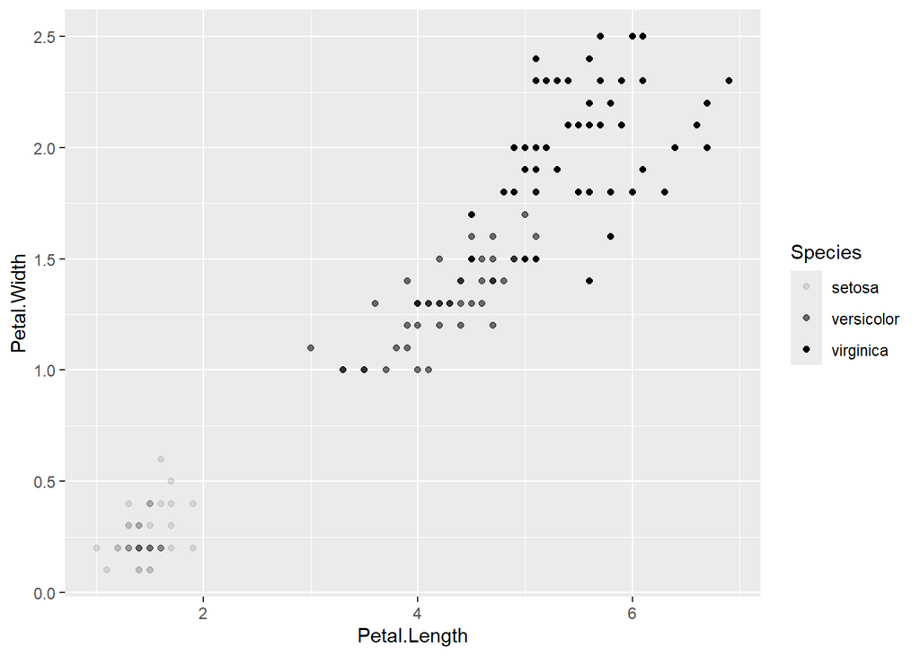

```r
# 심미성: 투명도
ggplot(data = iris, aes(x = Petal.Length, y = Petal.Width, alpha = Species)) +
    geom_point()
```

심미성 요소는 `ggplot()` 내에서 글로벌하게 적용할 수도 있고, 기하 객체별로 로컬하게 적용할 수도 있다. 위에서 그린 산점도를 보면 꽃잎 길이와 너비 사이의 정적(positive) 관계를 확인할 수 있는데, 이를 표현하는 추세선을 그리고자 한다. 이때 `color` 심미성 요소를 글로벌하게 적용하느냐, 로컬하게 적용하느냐에 따라 다른 결과를 얻게 된다. 추세선은 `geom_smooth()`를 이용하여 그릴 수 있으며, 하나의 그래프에 복수의 기하 객체를 담고 싶다면 `+`로 연결해주면 된다.

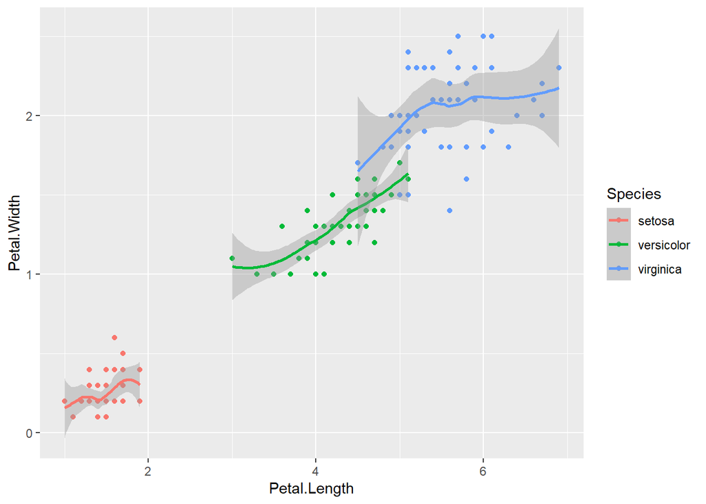

```r
# 글로벌하게 적용
ggplot(data = iris, aes(x = Petal.Length, y = Petal.Width, color = Species)) +
    geom_point() +
    geom_smooth()
```

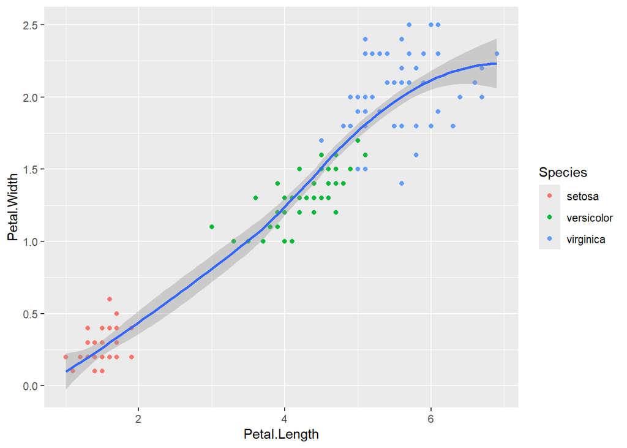

```r
# 로컬하게 적용
ggplot(data = iris, aes(x = Petal.Length, y = Petal.Width)) +
    geom_point(aes(color = Species)) +
    geom_smooth()
```

## 2.3 기하 객체

기하 객체(geometric objects)는 데이터가 시각적으로 표현되는 구체적인 형태를 의미하는데, `ggplot2` 패키지에서는 `geom_`으로 시작하는 함수로 나타낸다. 점, 선, 막대, 히스토그램, 박스플롯 등 다양한 기하 객체가 존재하며 사용자가 그리고자 하는 그래프 유형에 따라 적절하게 선택할 수 있다. 위에서 사용한 `geom_point()`도 점을 표현하는 기하 객체이다.

`geom_line()`을 사용하면 선을 표현할 수 있다. 관측 순서에 따른 꽃잎 길이에 대한 꺾은선 그래프를 그려보자.

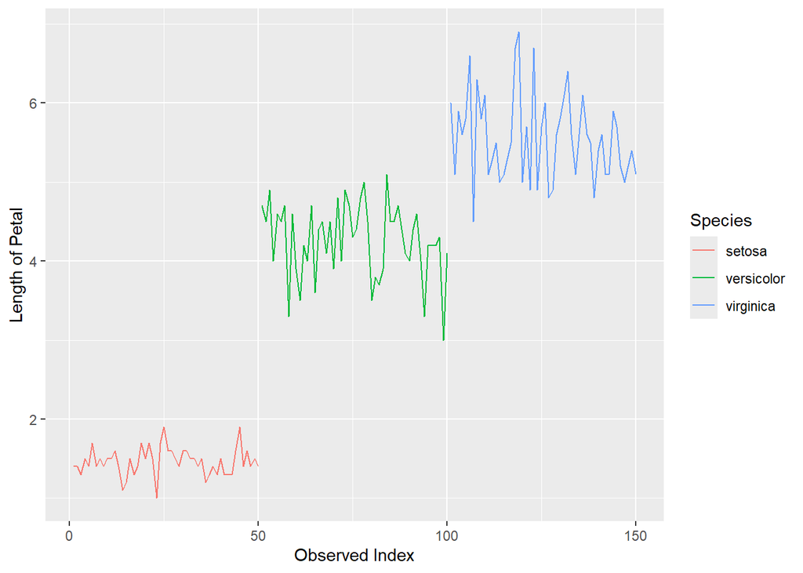

```r
ggplot(data = iris, aes(x = 1:150, y = Petal.Length, color = Species)) +
    geom_line() +
    labs(
        x = "Observed Index",
        y = "Length of Petal"
    )
```

`geom_bar()`와 `geom_col()`은 막대 그래프를 그린다. 여기서는 `geom_col()`를 사용해 종별 평균 꽃잎 길이를 나타내는 그래프를 그려보자.

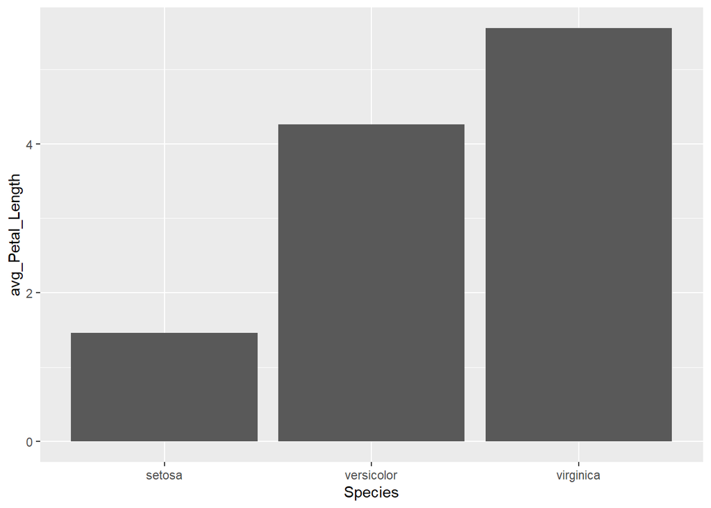

```r
# 종별 평균 꽃잎 길이 구하기
iris_avg <- iris |>
    group_by(Species) |>
    summarise(avg_Petal_Length = mean(Petal.Length))

# 종별 평균 꽃잎 길이
ggplot(data = iris_avg, aes(x = Species, y = avg_Petal_Length)) +
    geom_col()
```

`geom_histogram()`는 히스토그램을 그린다. 꽃잎 길이에 대한 히스토그램을 그려보자. `binwidth` 옵션은 히스토그램의 구간을 설정한다.

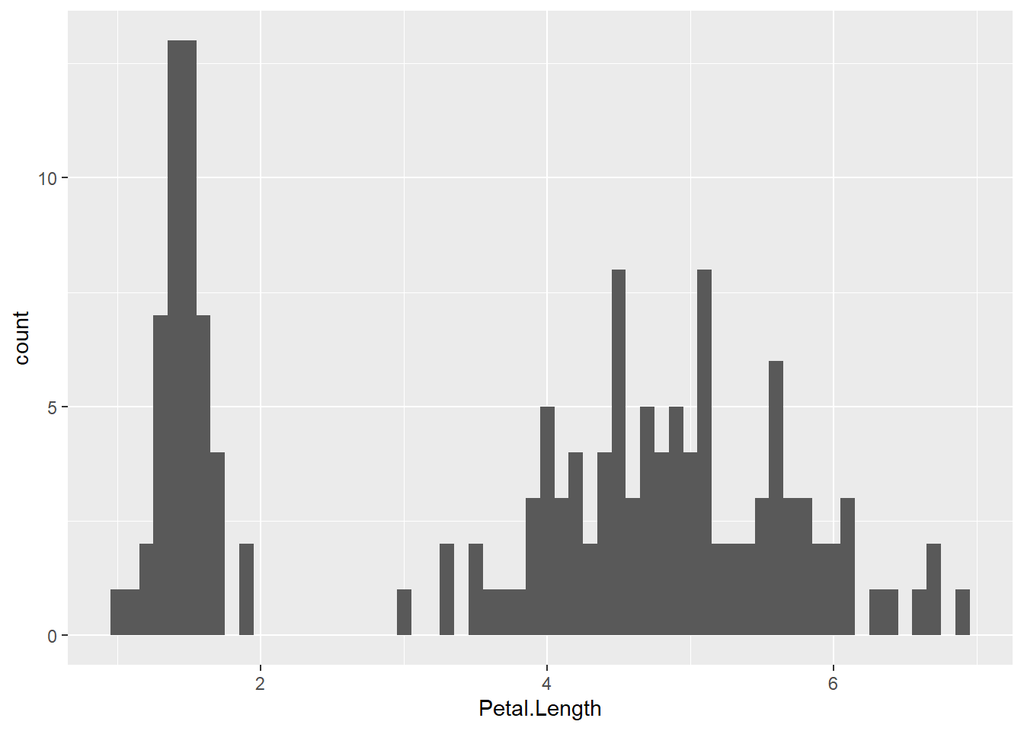

```r
ggplot(data = iris, aes(x = Petal.Length)) +
    geom_histogram(binwidth = 0.1)
```

`geom_boxplot()`은 박스플롯을 그린다. 종별 꽃잎 길이에 대한 박스플롯을 그려보자. 종의 구분은 색상으로 한다.

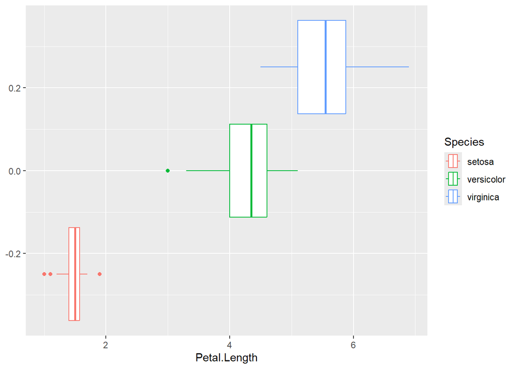

```r
ggplot(data = iris, aes(x = Petal.Length, color = Species)) +
    geom_boxplot()
```

# 3 추가 레이어

## 3.1 스케일

스케일(scale)은 심미성을 세부적으로 조정하는 역할을 하며, `scale_<aesthetic>_<type>()` 형태로 사용된다.

- `<aesthetic>` : `x`, `y`, `color`, `fill`, `size`, `shape` 등
- `<type>` : `continuous`, `discrete`, `manual`, `gradient`, `log10`, 등

앞서 그린 꽃잎의 길이와 너비에 대한 산점도를 다시 살펴보자.

```r
ggplot(data = iris, aes(x = Petal.Length, y = Petal.Width, color = Species)) +
    geom_point()
```

이는 아래 코드처럼 `ggplot2`가 자동으로 적용한 세 가지 스케일 설정에 의거해 만들어진 것이다.

```r
ggplot(data = iris, aes(x = Petal.Length, y = Petal.Width, color = Species)) +
    geom_point() +
    scale_x_continuous() +
    scale_y_continuous() +
    scale_color_discrete()
```

스케일 함수의 아규먼트를 수정하면 보다 세밀한 심미성 조정이 가능하다.

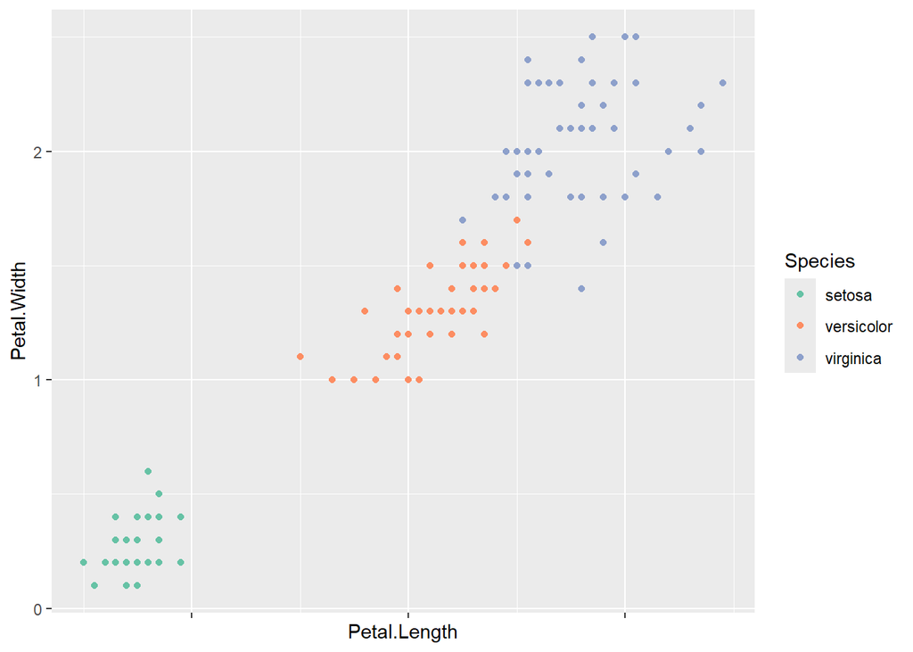

```r
ggplot(data = iris, aes(x = Petal.Length, y = Petal.Width, color = Species)) +
    geom_point() +
    scale_x_continuous(labels = NULL) +  # x축 표시하지 않음
    scale_y_continuous(breaks = seq(0, 3, by = 1)) + # y축 구간 설정
    scale_color_brewer(palette = "Set2") # 컬러 팔레트 설정
```

**ColorBrewer**

`scale_color_brewer()` 함수는 [ColorBrewer](https://colorbrewer2.org/#type=sequential&scheme=BuGn&n=3) 컬러 스케일을 사용한 것인데 익히고 있으면 많은 도움이 된다. 살펴보면 양적인 변수에 적용하기 좋은 팔레트가 있고, 질적인 변수에 적용하기 좋은 팔레트도 있다. 마음에 드는 팔레트를 골라 그래프의 색상 팔레트를 바꿔보자.

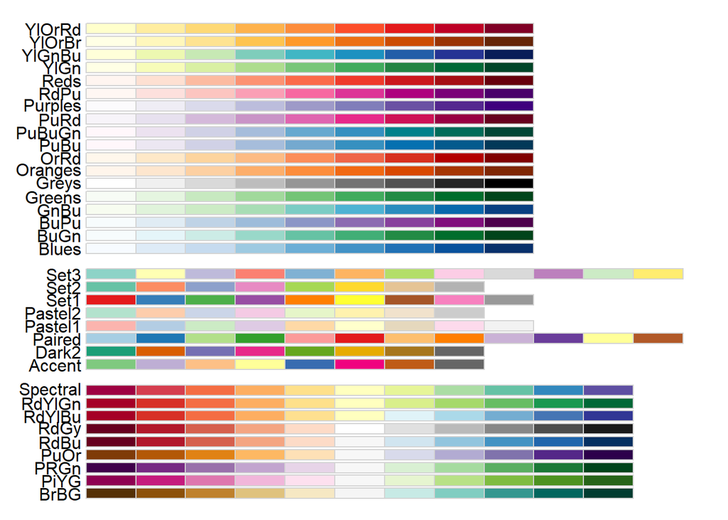

**직접 색상 지정하기**

내가 원하는 색상을 골라 직접 지정하는 방법도 있다. `scale_color_brewer()` 대신 `scale_color_manual()` 함수를 사용하면 된다. 또한 RGB 색상에 대한 html 코드를 사용해도 되고, R에서 부여한 657개의 이름 중에서 골라 사용해도 된다. 색상 이름 및 html 코드는 [다음 사이트](https://www.stat.auckland.ac.nz/~ihaka/courses/787/R-colours-a4.pdf)를 참고하라.

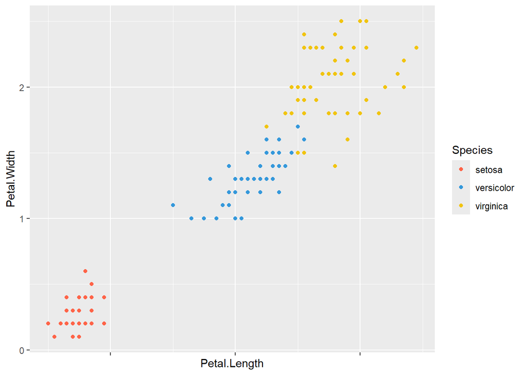

```r
ggplot(data = iris, aes(x = Petal.Length, y = Petal.Width, color = Species)) +
    geom_point() +
    scale_x_continuous(labels = NULL) +
    scale_y_continuous(breaks = seq(0, 3, by = 1)) +
    scale_color_manual(
        values = c(
            "setosa" = "Tomato",
            "versicolor" = "#3498DB",
            "virginica" = "#F1C40F"
            ) # 컬러 팔레트 직접 설정
        )
```

## 3.2 좌표

좌표(coordinates) 레이어 혹은 좌표계(coordinate systems)는 그래픽 요소들의 위치 결정에 기준이 되는 준거체계이다. `coord_flip()` 함수가 대표적이다.

`coord_flip()`은 축을 전환한다. 종별 꽃잎 길이에 대한 박스플롯의 축을 바꿔 보다 보기 편하게 그려보자.

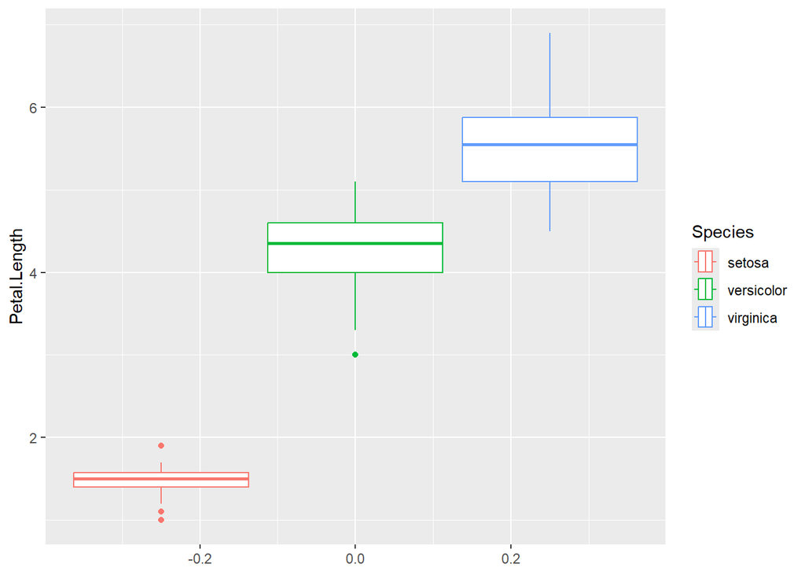

```r
ggplot(data = iris, aes(x = Petal.Length, color = Species)) +
    geom_boxplot() +
    coord_flip()
```

## 3.3 테마

`ggplot2` 패키지는 다양한 complete 테마를 제공하고 있으며 `theme_*()` 함수를 이용해 설정 가능하다. [여기](https://ggplot2.tidyverse.org/reference/ggtheme.html)에서 확인한 후 마음에 드는 테마로 설정해보자.

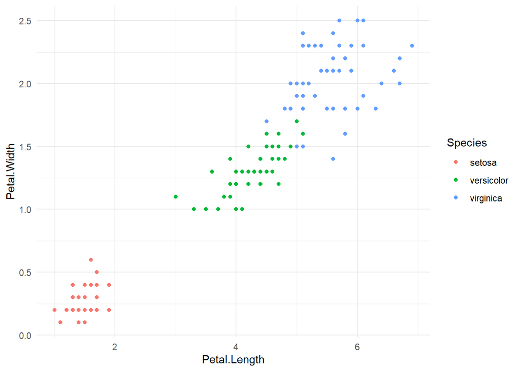

```r
ggplot(data = iris, aes(x = Petal.Length, y = Petal.Width, color = Species)) +
    geom_point() +
    theme_minimal()
```

`theme()` 함수를 사용하여 요소별로 하나씩 수정할 수도 있다. 수정 가능한 요소는 [여기](https://ggplot2.tidyverse.org/reference/theme.html)를 확인하라. 아래는 범례의 배열 방식과 위치를 수정한 것이다.

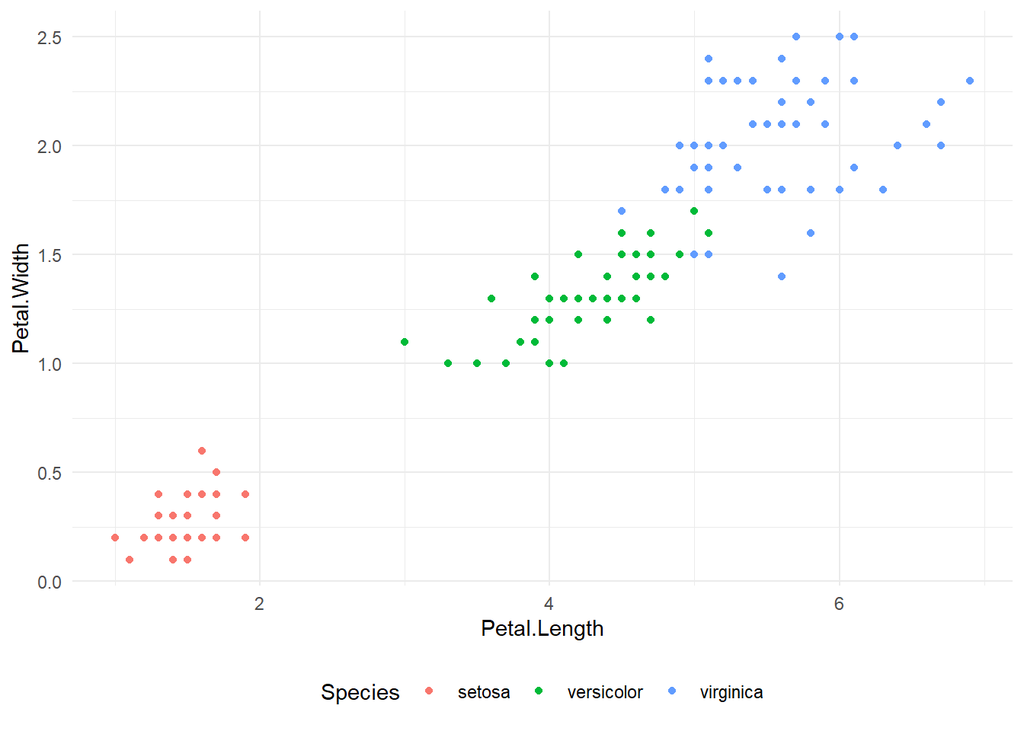

```r
ggplot(data = iris, aes(x = Petal.Length, y = Petal.Width, color = Species)) +
    geom_point() +
    theme_minimal() +
    theme(
        legend.direction = "horizontal",
        legend.position = "bottom"
    )
```

# 4 세부 설정

## 4.1 라벨

`labs()` 함수를 이용하면 그래프에 다양한 종류의 라벨을 설정할 수 있다.

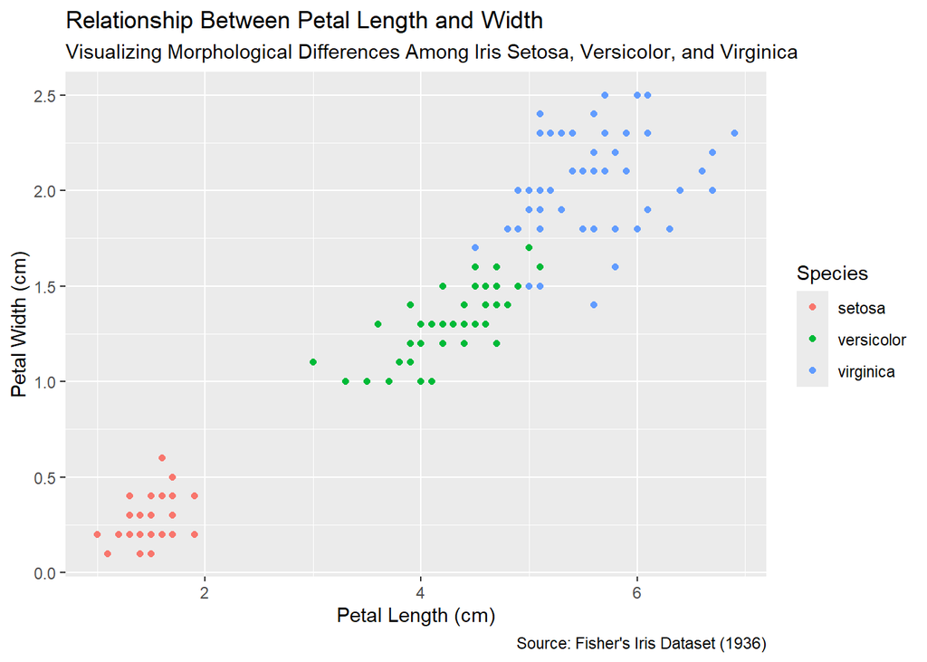

```r
ggplot(data = iris, aes(x = Petal.Length, y = Petal.Width, color = Species)) +
    geom_point() +
    labs(
        title = "Relationship Between Petal Length and Width", # 그래프 제목
        subtitle = "Visualizing Morphological Differences Among Iris Setosa, Versicolor, and Virginica", # 부제
        x = "Petal Length (cm)", # x축 제목
        y = "Petal Width (cm)", # y축 제목
        color = "Species", # 범례 제목
        caption = "Source: Fisher's Iris Dataset (1936)" # 주석
    )
```

## 4.2 그래프 저장

두 가지 방식이 있다. **첫 번째 방식**은 Output 창의 Plots 탭에 있는 Export 버튼은 이용하는 것이다. 다양한 그래픽 포멧 뿐만 아니라 pdf 형식으로도 저장할 수 있다. 저장 경로와 저장명, 그래프의 폭과 너비를 설정 후 `save` 버튼을 누르면 이미지가 저장된다.

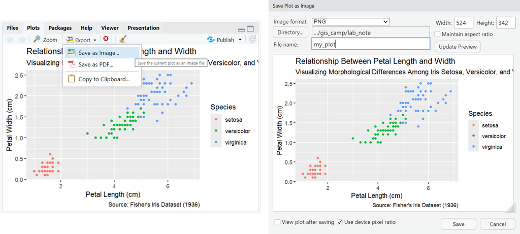

**두 번째 방식**은 `ggplot2` 패키지의 `ggsave()` 함수를 이용하는 것이다. 결과물의 가로-세로 비, 해상도 등을 종합적으로 고려하여 최적의 세팅값을 찾아야 한다. 디바이스에 따라 동일한 세팅값이 다른 결과를 산출하기도 한다.

```r
my_plot <- ggplot(data = iris, aes(x = Petal.Length, y = Petal.Width, color = Species)) +
    geom_point() +
    labs(
        title = "Relationship Between Petal Length and Width", # 그래프 제목
        subtitle = "Visualizing Morphological Differences Among Iris Setosa, Versicolor, and Virginica", # 부제
        x = "Petal Length (cm)", # x축 제목
        y = "Petal Width (cm)", # y축 제목
        color = "Species", # 범례 제목
    ) +
    theme_minimal()

ggsave(filename = "my_plot.png", plot = my_plot, width = 8, height = 6, dpi = 600)
```

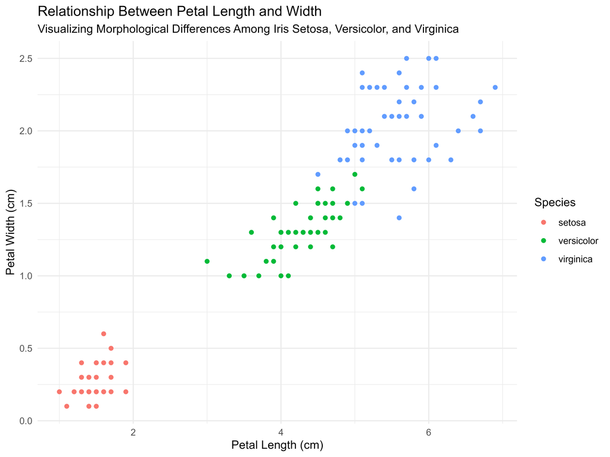